# Macrophage response to LPS

Jonathan Bean

2019-10-27

This project is looking at macrophage gene expression response to LPS in two different tissues, Liver and Heart at two different time points, 4 hours and 2 weeks post injection, as well as, a PBS injection control. The project involves a ribosomal tagging technique that is Cre / LoxP dependent. The Cre driver is specific for macrophages and there is an HA - tag that is only exposed after Cre LoxP recombination on Rpl22, a gene that encodes a protein that associates with ribosomes. A small portion of tissue homogenate is saved for a background reading and is denoted here as ‘N’ for input, while the bulk to the homogenate is used for immunoprecipitating polyribosomes specifically from macrophages, labeled ‘IP’ here.

Libraries required for project

```r
##############libraries################
#install.packages('tidyr')
#install.packages('dplyr')
#install.packages('ggplot2')
#install.packages('limma')
#install.packages('extrafont')
#loadfonts()
#install.packages('ggfortify')
#install.packages('tidyverse')


library(tidyr)
library(dplyr)
library(ggplot2)
library(limma)
library(extrafont)
library(ggfortify)
library(tidyverse)
```

Import dataset and save as an object. Discard unneeded columns from dataset. I am keeping ’tracking_id“,”condition“, and”FPKM" values and saving this as a second object.

```r
cuffnorm1 <- read.delim("../cuffnorm3/genes.read_group_tracking")

cuffnorm2 <- cuffnorm1[,c(1,2,3,7)]
```

The output from cufflinks follows ‘The Grammar of Graphics’. This is a standard for anyone working with larger datasets within data focused coding languages like ‘R’, ‘Python’, or ‘Matlab’. However it is not easy to look at if trying to interact with the data in a spreadsheet like ‘excel’. This is the code to turn the output into something more friendly to look at in an excel file. (For a colleague).

First I will group at ‘tracking_id’, ‘condition’, and ‘replicate’ (There are no replicates here but this is totally artificial and only for ease of making the excel file). -4 indicates everything except variable 4 which is ‘FPKM’.

```r
cuffnorm3 <- cuffnorm2 %>% group_by_at(-4) %>%
  mutate(count=1:n()) %>% ungroup %>%
  spread(key = "condition","replicate", value = "FPKM")
```

Next I am renaming the variable ‘tracking_id’ to ‘gene’.

```r
colnames(cuffnorm3)[colnames(cuffnorm3)=="tracking_id"] <- "gene"
```

While the output file ‘cds.diff’ doesn’t populate with useful data it does provide a list of coding genes. I am importing that list here.

```r
coding <- read.delim('../cuffdiff/PBS_Liver_v_Heart/cds.diff') %>% select('gene')
```

Now I am using a filter to keep only the ’gene’s that are listed in the cds.diff file. I am deleted columns 2 and 3 as they do not contain any useful information.

```r
cuffnorm4 <- inner_join(cuffnorm3, coding, by = "gene")
cuffnorm4 <- cuffnorm4[,-c(2,3)]
```

Finally, I am writing this object out to a csv. I will then open this in a spreadsheet software and save it as an excel file. This is the file I gave to collaborating colleagues.

```r
write.csv(cuffnorm4, file = "LPS_timecourse_w_inputs_v3.csv")
```

For some reason the above manipulations caused the numeric output to transform into character data. Here I delete the column “gene” that contains character data, transform the numeric data back into numeric format, then add back the ‘gene’ column.

```r
cuffnorm5 <- cuffnorm4[,-1] %>% sapply(as.numeric)
cuffnorm5 <- cbind(cuffnorm4[1], cuffnorm5)
```

```r
view(cuffnorm5) %>% head()
```

```
##            gene Heart_LPS_2wk_IP1 Heart_LPS_2wk_IP2 Heart_LPS_2wk_N1
## 1 0610007P14Rik           5.41258           8.32471          4.87325
## 2 0610009B22Rik          19.36210          12.77160         48.42980
## 3 0610009O20Rik          14.00620          12.67610         51.03160
## 4 0610010F05Rik           2.50588           2.24890          1.17485
## 5 0610010K14Rik          31.96640          44.99740         29.45690
## 6 0610011F06Rik           3.83932           6.65563         14.25320
##   Heart_LPS_2wk_N2 Heart_LPS_4hr_IP1 Heart_LPS_4hr_IP2 Heart_LPS_4hr_N1
## 1          3.87245           0.42457           1.30158         0.841655
## 2         22.40070          11.77970          19.94190        42.477800
## 3         42.82400          19.58000          15.95780        51.031500
## 4          1.36187           1.24008           1.76551         1.663810
## 5         32.70600          13.19740          13.33590        32.114500
## 6         18.20220           4.87849           2.31705        16.084300
##   Heart_LPS_4hr_N2 Heart_PBS_IP1 Heart_PBS_IP2 Heart_PBS_N1 Heart_PBS_N2
```

[output cut: 27 more lines]

Here I add columns for average ‘input’, ‘IP’, and ‘IP/N’ for each condition. I add a small constant to the IP and N when doing division to avoid divided by zero errors.

```r
cuffnorm6 <- cuffnorm5 %>%  group_by(gene) %>%
  mutate(Liver_PBS_N = mean(c(Liver_PBS_N1,Liver_PBS_N2)),
         Liver_PBS_IP=mean(c(Liver_PBS_IP1, Liver_PBS_IP2)),
         Liver_PBS_Enr = ((Liver_PBS_IP + 0.01)/(Liver_PBS_N + 0.01)),
         Liver_LPS_4hr_N = mean(c(Liver_LPS_4hr_N1,Liver_LPS_4hr_N2)),
         Liver_LPS_4hr_IP =mean(c(Liver_LPS_4hr_IP1,Liver_LPS_4hr_IP2)),
         Liver_LPS_4hr_Enr = ((Liver_LPS_4hr_IP + 0.01)/(Liver_LPS_4hr_N + 0.01)),
         Liver_LPS_2wk_N = mean(c(Liver_LPS_2wk_N1,Liver_LPS_2wk_N2)),
         Liver_LPS_2wk_IP = mean(c(Liver_LPS_2wk_IP1,Liver_LPS_2wk_IP2)),
         Liver_LPS_2wk_Enr = ((Liver_LPS_2wk_IP + 0.01)/(Liver_LPS_2wk_N + 0.01)),
         Heart_PBS_N = mean(c(Heart_PBS_N1,Heart_PBS_N2)),
         Heart_PBS_IP=mean(c(Heart_PBS_IP1, Heart_PBS_IP2)),
         Heart_PBS_Enr = ((Heart_PBS_IP + 0.01)/(Heart_PBS_N + 0.01)),
         Heart_LPS_4hr_N = mean(c(Heart_LPS_4hr_N1,Heart_LPS_4hr_N2)),
         Heart_LPS_4hr_IP =mean(c(Heart_LPS_4hr_IP1,Heart_LPS_4hr_IP2)),
         Heart_LPS_4hr_Enr = ((Heart_LPS_4hr_IP + 0.01)/(Heart_LPS_4hr_N + 0.01)),
         Heart_LPS_2wk_N = mean(c(Heart_LPS_2wk_N1,Heart_LPS_2wk_N2)),
         Heart_LPS_2wk_IP = mean(c(Heart_LPS_2wk_IP1,Heart_LPS_2wk_IP2)),
         Heart_LPS_2wk_Enr = ((Heart_LPS_2wk_IP + 0.01)/(Heart_LPS_2wk_N + 0.01)))
```

```r
view(cuffnorm6) %>% head()
```

```
## # A tibble: 6 x 43
## # Groups:   gene [6]
##   gene  Heart_LPS_2wk_I… Heart_LPS_2wk_I… Heart_LPS_2wk_N1 Heart_LPS_2wk_N2
##   <chr>            <dbl>            <dbl>            <dbl>            <dbl>
## 1 0610…             5.41             8.32             4.87             3.87
## 2 0610…            19.4             12.8             48.4             22.4
## 3 0610…            14.0             12.7             51.0             42.8
## 4 0610…             2.51             2.25             1.17             1.36
## 5 0610…            32.0             45.0             29.5             32.7
## 6 0610…             3.84             6.66            14.3             18.2
## # … with 38 more variables: Heart_LPS_4hr_IP1 <dbl>,
## #   Heart_LPS_4hr_IP2 <dbl>, Heart_LPS_4hr_N1 <dbl>,
## #   Heart_LPS_4hr_N2 <dbl>, Heart_PBS_IP1 <dbl>, Heart_PBS_IP2 <dbl>,
## #   Heart_PBS_N1 <dbl>, Heart_PBS_N2 <dbl>, Liver_LPS_2wk_IP1 <dbl>,
## #   Liver_LPS_2wk_IP2 <dbl>, Liver_LPS_2wk_N1 <dbl>,
## #   Liver_LPS_2wk_N2 <dbl>, Liver_LPS_4hr_IP1 <dbl>,
## #   Liver_LPS_4hr_IP2 <dbl>, Liver_LPS_4hr_N1 <dbl>,
## #   Liver_LPS_4hr_N2 <dbl>, Liver_PBS_IP1 <dbl>, Liver_PBS_IP2 <dbl>,
## #   Liver_PBS_N1 <dbl>, Liver_PBS_N2 <dbl>, Liver_PBS_N <dbl>,
## #   Liver_PBS_IP <dbl>, Liver_PBS_Enr <dbl>, Liver_LPS_4hr_N <dbl>,
## #   Liver_LPS_4hr_IP <dbl>, Liver_LPS_4hr_Enr <dbl>,
## #   Liver_LPS_2wk_N <dbl>, Liver_LPS_2wk_IP <dbl>,
## #   Liver_LPS_2wk_Enr <dbl>, Heart_PBS_N <dbl>, Heart_PBS_IP <dbl>,
## #   Heart_PBS_Enr <dbl>, Heart_LPS_4hr_N <dbl>, Heart_LPS_4hr_IP <dbl>,
## #   Heart_LPS_4hr_Enr <dbl>, Heart_LPS_2wk_N <dbl>,
## #   Heart_LPS_2wk_IP <dbl>, Heart_LPS_2wk_Enr <dbl>
```

Next I identify genes that have greater than 5 FPKM in IP and 5 fold enriched IP over input for each condition and save each as an object that is a list of genes.

```r
Liver_PBS_Enriched <- cuffnorm6 %>% filter(Liver_PBS_Enr > 5, Liver_PBS_IP > 5) %>%
  select(gene)


Liver_LPS_4hr_Enriched <- cuffnorm6 %>% filter(Liver_LPS_4hr_Enr > 5, Liver_LPS_4hr_IP > 5) %>%
  select(gene)

Liver_LPS_2wk_Enriched <- cuffnorm6 %>% filter(Liver_LPS_2wk_Enr > 5, Liver_LPS_2wk_IP > 5) %>%
  select(gene)


Heart_PBS_Enriched <- cuffnorm6 %>% filter(Heart_PBS_Enr > 5, Heart_PBS_IP > 5) %>%
  select(gene)

Heart_LPS_4hr_Enriched <- cuffnorm6 %>% filter(Heart_LPS_4hr_Enr > 5, Heart_LPS_4hr_IP > 5) %>%
  select(gene)

Heart_LPS_2wk_Enriched <- cuffnorm6 %>% filter(Heart_LPS_2wk_Enr > 5, Heart_LPS_2wk_IP > 5) %>%
  select(gene)
```

I rename each condition column of ‘gene’ to match the condition it comes from.

```r
Liver_PBS_Enr <- Liver_PBS_Enriched %>% `colnames<-`('Liver.steady.state')
Liver_LPS_4hr_Enr <- Liver_LPS_4hr_Enriched %>% `colnames<-`('4hr.liver')
Liver_LPS_2wk_Enr <- Liver_LPS_2wk_Enriched %>% `colnames<-`('2wk.liver')
Heart_PBS_Enr <- Heart_PBS_Enriched %>% `colnames<-`('Heart.steady.state')
Heart_LPS_4hr_Enr <- Heart_LPS_4hr_Enriched %>% `colnames<-`('4hr.heart')
Heart_LPS_2wk_Enr <- Heart_LPS_2wk_Enriched %>% `colnames<-`('2wk.heart')
```

I want to join these list but ‘R’ requires the list be of equal length. First I determine what the longest length of list is and save this as an object.

```r
n2 <- max(nrow(Liver_PBS_Enr), nrow(Liver_LPS_4hr_Enr), nrow(Liver_LPS_2wk_Enr), nrow(Heart_PBS_Enr),
         nrow(Heart_LPS_4hr_Enr), nrow(Heart_LPS_2wk_Enr))
```

Now I am filling in ‘NA’ for values in list with less than maximum length. I am omitting the one list with the maximum length because when it was included it replace the final value with ‘NA’.

```r
Liver_PBS_Enr[nrow(Liver_PBS_Enr)+(n2 - nrow(Liver_PBS_Enr)),] <- NA
Liver_LPS_4hr_Enr[nrow(Liver_LPS_4hr_Enr)+(n2 - nrow(Liver_LPS_4hr_Enr)),] <- NA
Liver_LPS_2wk_Enr[nrow(Liver_LPS_2wk_Enr)+(n2 - nrow(Liver_LPS_2wk_Enr)),] <- NA
Heart_PBS_Enr[nrow(Heart_PBS_Enr)+(n2 - nrow(Heart_PBS_Enr)),] <- NA

Heart_LPS_2wk_Enr[nrow(Heart_LPS_2wk_Enr)+(n2 - nrow(Heart_LPS_2wk_Enr)),] <- NA
```

Now I am able to join the list. I save this as a csv that I later open in spreadsheet software and save as an excel file. Colleagues’ request.

```r
Enr_list <- bind_cols(Liver_PBS_Enr, Liver_LPS_4hr_Enr, Liver_LPS_2wk_Enr,
                      Heart_PBS_Enr, Heart_LPS_4hr_Enr, Heart_LPS_2wk_Enr)
write.csv(Enr_list, file = 'Enriched_genes_v4.csv', na='', row.names = FALSE)

view(Enr_list) %>% head(n=10)
```

```
## # A tibble: 10 x 6
##    Liver.steady.st… `4hr.liver` `2wk.liver` Heart.steady.st… `4hr.heart`
##    <chr>            <chr>       <chr>       <chr>            <chr>
##  1 1700003F12Rik    2510009E07… 1700003F12… 1600002K03Rik    4632428N05…
##  2 1700026L06Rik    4930486L24… 2510009E07… 2610524H06Rik    5031414D18…
##  3 1700056E22Rik    5031414D18… 4632428N05… 4632428N05Rik    5430427O19…
##  4 1810011H11Rik    6330416G13… 6330416G13… 9930111J21Rik1   5730508B09…
##  5 2510009E07Rik    A630001G21… 6430548M08… A430078G23Rik    A230046K03…
##  6 4632428N05Rik    AB124611    9930111J21… AB124611         A530032D15…
##  7 5031439G07Rik    Abca9       AB124611    Abca1            A630001G21…
##  8 6330416G13Rik    Abcc1       Abca9       Abca7            AB124611
##  9 6430548M08Rik    Abcc4       Abcc1       Abca9            Abca9
## 10 9930111J21Rik1   Abcg1       Abcg1       Abcc3            Abi1
## # … with 1 more variable: `2wk.heart` <chr>
```

I am now import a list of transcription factors from - I’ve lost the source because of a deactivated email - but my collaborating colleague should still have it. I downloaded the file now I am importing it and saving the column with the ‘gene’ information.

```r
TSF <- read.delim('../TSF.txt') %>% select('gene')
```

Now I filter the list of enriched genes saving only those that appear on the transcription factors list. Again I rename each ‘gene’ column to match the condition it comes from.

```r
TF_Liver_PBS_Enr <- Liver_PBS_Enriched %>% inner_join(TSF, by = 'gene') %>% `colnames<-`('Liver.steady.state')
TF_Liver_LPS_4hr_Enr <- Liver_LPS_4hr_Enriched %>% inner_join(TSF, by = 'gene') %>% `colnames<-`('4hr.liver')
TF_Liver_LPS_2wk_Enr <- Liver_LPS_2wk_Enriched %>% inner_join(TSF, by = 'gene') %>% `colnames<-`('2wk.liver')
TF_Heart_PBS_Enr <- Heart_PBS_Enriched %>% inner_join(TSF, by = 'gene') %>% `colnames<-`('Heart.steady.state')
TF_Heart_LPS_4hr_Enr <- Heart_LPS_4hr_Enriched %>% inner_join(TSF, by = 'gene') %>% `colnames<-`('4hr.heart')
TF_Heart_LPS_2wk_Enr <- Heart_LPS_2wk_Enriched %>% inner_join(TSF, by = 'gene') %>% `colnames<-`('2wk.heart')
```

I am looking for the longest length of list among these conditions.

```r
n3 <- max(nrow(TF_Liver_PBS_Enr), nrow(TF_Liver_LPS_4hr_Enr), nrow(TF_Liver_LPS_2wk_Enr),
          nrow(TF_Heart_PBS_Enr), nrow(TF_Heart_LPS_4hr_Enr), nrow(TF_Heart_LPS_2wk_Enr))
```

Using the maximum length I fill in ‘NA’ in the lists shorter than the maximum length.

```r
TF_Liver_PBS_Enr[nrow(TF_Liver_PBS_Enr)+(n3 - nrow(TF_Liver_PBS_Enr)),] <- NA
TF_Liver_LPS_4hr_Enr[nrow(TF_Liver_LPS_4hr_Enr)+(n3 - nrow(TF_Liver_LPS_4hr_Enr)),] <- NA
TF_Liver_LPS_2wk_Enr[nrow(TF_Liver_LPS_2wk_Enr)+(n3 - nrow(TF_Liver_LPS_2wk_Enr)),] <- NA
TF_Heart_PBS_Enr[nrow(TF_Heart_PBS_Enr)+(n3 - nrow(TF_Heart_PBS_Enr)),] <- NA

TF_Heart_LPS_2wk_Enr[nrow(TF_Heart_LPS_2wk_Enr)+(n3 - nrow(TF_Heart_LPS_2wk_Enr)),] <- NA
```

I now join the list and write this as a csv. Later I open this in a spreadsheet software and save it as an excel file for my colleagues use.

```r
TF_enr_list2 <- bind_cols(TF_Liver_PBS_Enr, TF_Liver_LPS_4hr_Enr, TF_Liver_LPS_2wk_Enr,
                          TF_Heart_PBS_Enr, TF_Heart_LPS_4hr_Enr, TF_Heart_LPS_2wk_Enr)
write.csv(TF_enr_list2, file = 'TF_Enriched_genes_v4.csv', na='', row.names = FALSE)

view(TF_enr_list2) %>% head()
```

```
## # A tibble: 6 x 6
##   Liver.steady.st… `4hr.liver` `2wk.liver` Heart.steady.st… `4hr.heart`
##   <chr>            <chr>       <chr>       <chr>            <chr>
## 1 Akna             Aebp2       Akna        Akna             Ahr
## 2 Atf3             Akna        Batf        Batf             Akna
## 3 Batf             Batf        Batf3       Batf3            Bach1
## 4 Batf3            Batf3       Btbd11      Cebpa            Batf
## 5 Btbd11           Cebpb       Cebpb       Fos              Cebpb
## 6 Cebpb            Creb5       Elf4        Hcfc1            Etv3
## # … with 1 more variable: `2wk.heart` <chr>
```

I want to make a scatter plot of input vs IP values and highlight the genes I identified as enriched earlier. I create an object for each condition that includes the input and IP values and create an additional column that identifies whether or not the gene is considered enriched ‘Enr’ (IP > 5 FPKM, IP/N > 5).

```r
Liver_PBS <- cuffnorm6 %>% inner_join(Liver_PBS_Enriched) %>%
  select(gene, Liver_PBS_N1, Liver_PBS_N2,Liver_PBS_IP1,Liver_PBS_IP2, Liver_PBS_N,Liver_PBS_IP, Liver_PBS_Enr) %>%
  mutate(Enr = 'yes')
temp001 <- cuffnorm6 %>% anti_join(Liver_PBS_Enriched) %>%
  select(gene, Liver_PBS_N1, Liver_PBS_N2,Liver_PBS_IP1,Liver_PBS_IP2, Liver_PBS_N,Liver_PBS_IP, Liver_PBS_Enr) %>%
  mutate(Enr = 'no')
Liver_PBS <- rbind(Liver_PBS, temp001)


Liver_LPS_4hr <- cuffnorm6 %>% inner_join(Liver_LPS_4hr_Enriched) %>%
  select(gene, Liver_LPS_4hr_N1, Liver_LPS_4hr_N2,Liver_LPS_4hr_IP1,Liver_LPS_4hr_IP2, Liver_LPS_4hr_N,Liver_LPS_4hr_IP, Liver_LPS_4hr_Enr) %>%
  mutate(Enr = 'yes')
temp002 <- cuffnorm6 %>% anti_join(Liver_LPS_4hr_Enriched) %>%
  select(gene, Liver_LPS_4hr_N1, Liver_LPS_4hr_N2,Liver_LPS_4hr_IP1,Liver_LPS_4hr_IP2, Liver_LPS_4hr_N,Liver_LPS_4hr_IP, Liver_LPS_4hr_Enr) %>%
  mutate(Enr = 'no')
Liver_LPS_4hr <- rbind(Liver_LPS_4hr, temp002)


Liver_LPS_2wk <- cuffnorm6 %>% inner_join(Liver_LPS_2wk_Enriched) %>%
  select(gene, Liver_LPS_2wk_N1, Liver_LPS_2wk_N2,Liver_LPS_2wk_IP1,Liver_LPS_2wk_IP2, Liver_LPS_2wk_N,Liver_LPS_2wk_IP, Liver_LPS_2wk_Enr) %>%
  mutate(Enr = 'yes')
temp003 <- cuffnorm6 %>% anti_join(Liver_LPS_2wk_Enriched) %>%
  select(gene, Liver_LPS_2wk_N1, Liver_LPS_2wk_N2,Liver_LPS_2wk_IP1,Liver_LPS_2wk_IP2, Liver_LPS_2wk_N,Liver_LPS_2wk_IP, Liver_LPS_2wk_Enr) %>%
  mutate(Enr = 'no')
Liver_LPS_2wk <- rbind(Liver_LPS_2wk, temp003)




Heart_PBS <- cuffnorm6 %>% inner_join(Heart_PBS_Enriched) %>%
  select(gene, Heart_PBS_N1, Heart_PBS_N2,Heart_PBS_IP1,Heart_PBS_IP2, Heart_PBS_N,Heart_PBS_IP, Heart_PBS_Enr) %>%
  mutate(Enr = 'yes')
temp004 <- cuffnorm6 %>% anti_join(Heart_PBS_Enriched) %>%
  select(gene, Heart_PBS_N1, Heart_PBS_N2,Heart_PBS_IP1,Heart_PBS_IP2, Heart_PBS_N,Heart_PBS_IP, Heart_PBS_Enr) %>%
  mutate(Enr = 'no')
Heart_PBS <- rbind(Heart_PBS, temp004)


Heart_LPS_4hr <- cuffnorm6 %>% inner_join(Heart_LPS_4hr_Enriched) %>%
  select(gene, Heart_LPS_4hr_N1, Heart_LPS_4hr_N2,Heart_LPS_4hr_IP1,Heart_LPS_4hr_IP2, Heart_LPS_4hr_N,Heart_LPS_4hr_IP, Heart_LPS_4hr_Enr) %>%
  mutate(Enr = 'yes')
temp005 <- cuffnorm6 %>% anti_join(Heart_LPS_4hr_Enriched) %>%
  select(gene, Heart_LPS_4hr_N1, Heart_LPS_4hr_N2,Heart_LPS_4hr_IP1,Heart_LPS_4hr_IP2, Heart_LPS_4hr_N,Heart_LPS_4hr_IP, Heart_LPS_4hr_Enr) %>%
  mutate(Enr = 'no')
Heart_LPS_4hr <- rbind(Heart_LPS_4hr, temp005)


Heart_LPS_2wk <- cuffnorm6 %>% inner_join(Heart_LPS_2wk_Enriched) %>%
  select(gene, Heart_LPS_2wk_N1, Heart_LPS_2wk_N2,Heart_LPS_2wk_IP1,Heart_LPS_2wk_IP2, Heart_LPS_2wk_N,Heart_LPS_2wk_IP, Heart_LPS_2wk_Enr) %>%
  mutate(Enr = 'yes')
temp006 <- cuffnorm6 %>% anti_join(Heart_LPS_2wk_Enriched) %>%
  select(gene, Heart_LPS_2wk_N1, Heart_LPS_2wk_N2,Heart_LPS_2wk_IP1,Heart_LPS_2wk_IP2, Heart_LPS_2wk_N,Heart_LPS_2wk_IP, Heart_LPS_2wk_Enr) %>%
  mutate(Enr = 'no')
Heart_LPS_2wk <- rbind(Heart_LPS_2wk, temp006)
```

Now I will plot each condition input vs IP transforming FPKM by log2. I am adding a small constant to avoid log2 zero errors.

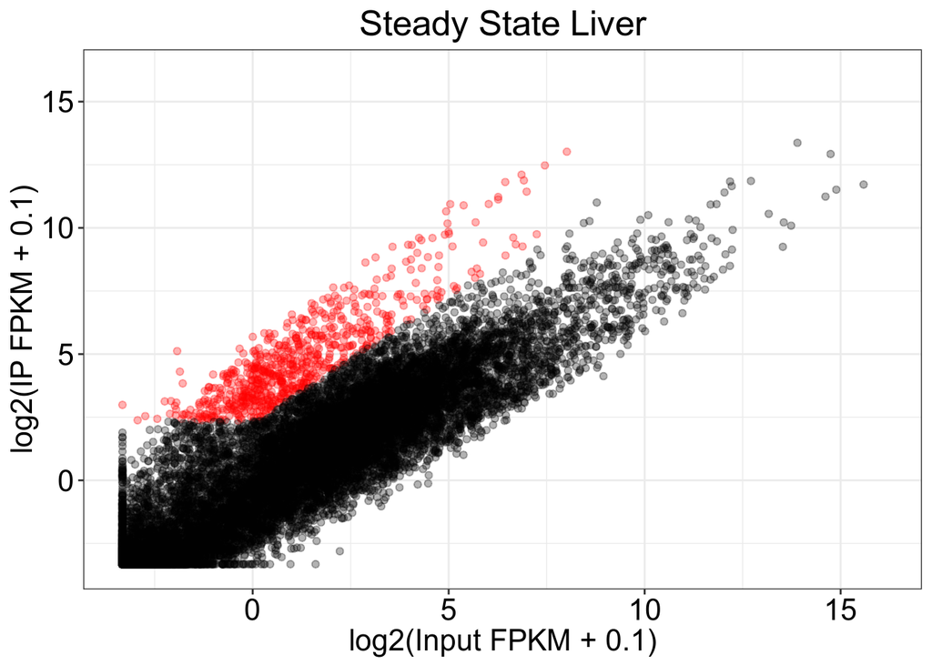

```r
Liver_PBS %>%
  ggplot(aes(log2(Liver_PBS_N +0.1), log2(Liver_PBS_IP+0.1), color = Enr)) +
  geom_point(alpha = 0.3)  + scale_color_manual(values=c("black", "red")) +
  theme_bw()  +
  labs(x = "log2(Input FPKM + 0.1)", y = "log2(IP FPKM + 0.1)",
       title = "Steady State Liver", family = 'Arial') +
  theme(plot.title = element_text(hjust = 0.5)) +
  theme(text = element_text(size = 16, family='Arial'), axis.text.x = element_text(size = 16, family = 'Arial', color = 'black'),
        axis.text.y = element_text(size = 16, family = 'Arial', color = 'black')) +
  theme(legend.position="none") +
  scale_x_continuous(limits=c(-3.35,16.1), breaks = c(0, 5, 10, 15)) +
  scale_y_continuous(limits=c(-3.35,16.1), breaks = c(0, 5, 10, 15))
```

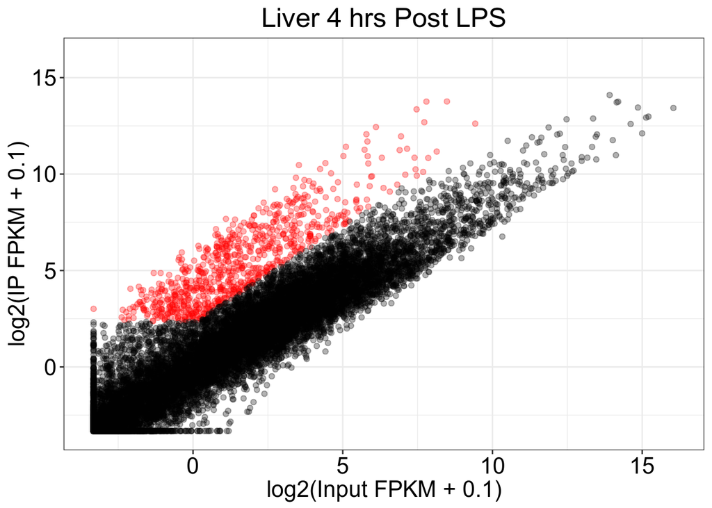

```r
Liver_LPS_4hr %>%
  ggplot(aes(log2(Liver_LPS_4hr_N +0.1), log2(Liver_LPS_4hr_IP+0.1), color = Enr)) +
  geom_point(alpha = 0.3)  + scale_color_manual(values=c("black", "red")) +
  theme_bw()  +
  labs(x = "log2(Input FPKM + 0.1)", y = "log2(IP FPKM + 0.1)",
       title = "Liver 4 hrs Post LPS", family = 'Arial') +
  theme(plot.title = element_text(hjust = 0.5)) +
  theme(text = element_text(size = 16, family='Arial'), axis.text.x = element_text(size = 16, family = 'Arial', color = 'black'),
        axis.text.y = element_text(size = 16, family = 'Arial', color = 'black')) +
  theme(legend.position="none") +
  scale_x_continuous(limits=c(-3.35,16.1), breaks = c(0, 5, 10, 15)) +
  scale_y_continuous(limits=c(-3.35,16.1), breaks = c(0, 5, 10, 15))
```

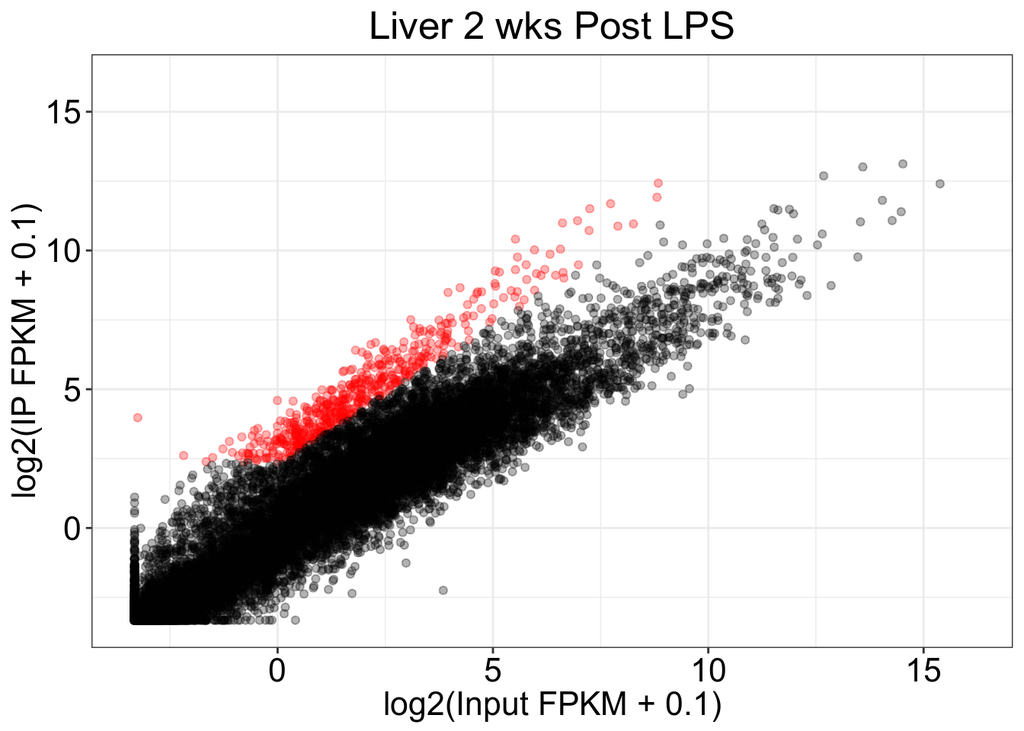

```r
Liver_LPS_2wk %>%
  ggplot(aes(log2(Liver_LPS_2wk_N +0.1), log2(Liver_LPS_2wk_IP+0.1), color = Enr)) +
  geom_point(alpha = 0.3)  + scale_color_manual(values=c("black", "red")) +
  theme_bw()  +
  labs(x = "log2(Input FPKM + 0.1)", y = "log2(IP FPKM + 0.1)",
       title = "Liver 2 wks Post LPS", family = 'Arial') +
  theme(plot.title = element_text(hjust = 0.5)) +
  theme(text = element_text(size = 16, family='Arial'), axis.text.x = element_text(size = 16, family = 'Arial', color = 'black'),
        axis.text.y = element_text(size = 16, family = 'Arial', color = 'black')) +
  theme(legend.position="none") +
  scale_x_continuous(limits=c(-3.35,16.1), breaks = c(0, 5, 10, 15)) +
  scale_y_continuous(limits=c(-3.35,16.1), breaks = c(0, 5, 10, 15))
```

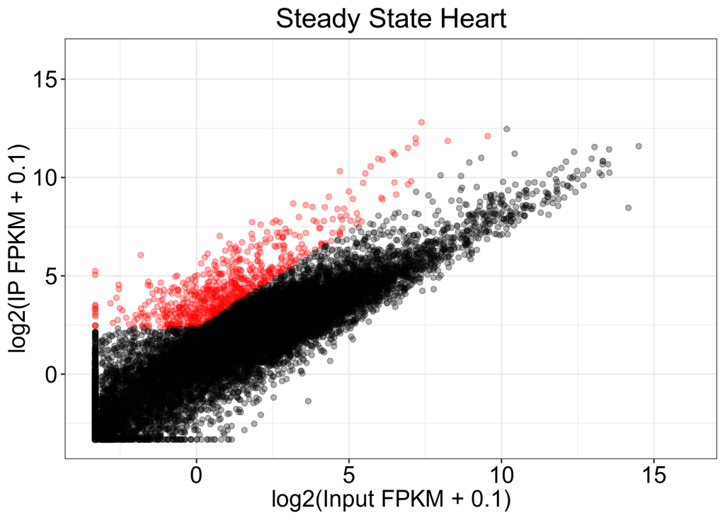

```r
Heart_PBS %>%
  ggplot(aes(log2(Heart_PBS_N +0.1), log2(Heart_PBS_IP+0.1), color = Enr)) +
  geom_point(alpha = 0.3)  + scale_color_manual(values=c("black", "red")) +
  theme_bw()  +
  labs(x = "log2(Input FPKM + 0.1)", y = "log2(IP FPKM + 0.1)",
       title = "Steady State Heart", family = 'Arial') +
  theme(plot.title = element_text(hjust = 0.5)) +
  theme(text = element_text(size = 16, family='Arial'), axis.text.x = element_text(size = 16, family = 'Arial', color = 'black'),
        axis.text.y = element_text(size = 16, family = 'Arial', color = 'black')) +
  theme(legend.position="none") +
  scale_x_continuous(limits=c(-3.35,16.1), breaks = c(0, 5, 10, 15)) +
  scale_y_continuous(limits=c(-3.35,16.1), breaks = c(0, 5, 10, 15))
```

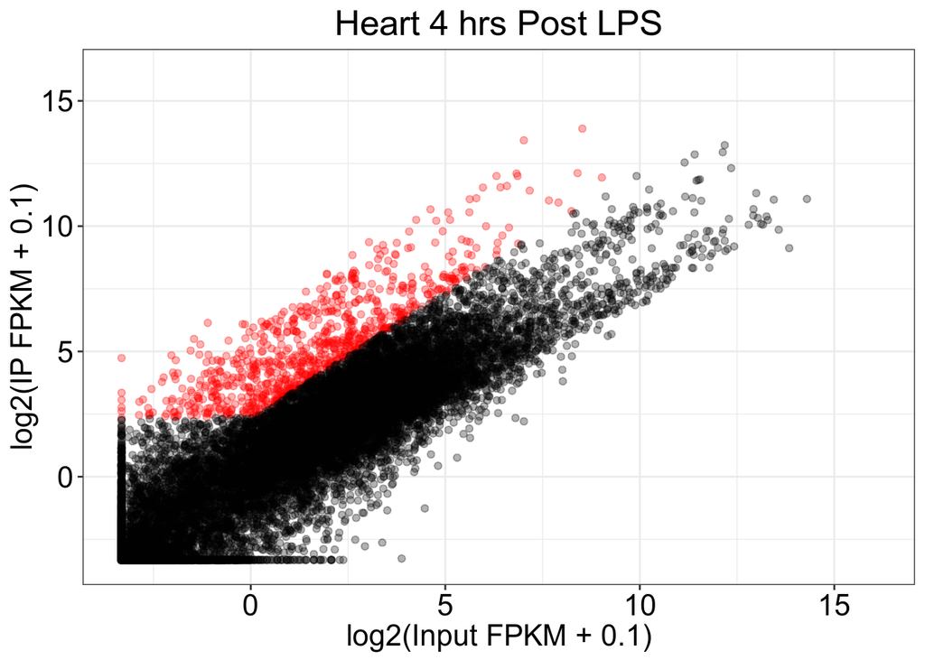

```r
Heart_LPS_4hr %>%
  ggplot(aes(log2(Heart_LPS_4hr_N +0.1), log2(Heart_LPS_4hr_IP+0.1), color = Enr)) +
  geom_point(alpha = 0.3)  + scale_color_manual(values=c("black", "red")) +
  theme_bw()  +
  labs(x = "log2(Input FPKM + 0.1)", y = "log2(IP FPKM + 0.1)",
       title = "Heart 4 hrs Post LPS", family = 'Arial') +
  theme(plot.title = element_text(hjust = 0.5)) +
  theme(text = element_text(size = 16, family='Arial'), axis.text.x = element_text(size = 16, family = 'Arial', color = 'black'),
        axis.text.y = element_text(size = 16, family = 'Arial', color = 'black')) +
  theme(legend.position="none") +
  scale_x_continuous(limits=c(-3.35,16.1), breaks = c(0, 5, 10, 15)) +
  scale_y_continuous(limits=c(-3.35,16.1), breaks = c(0, 5, 10, 15))
```

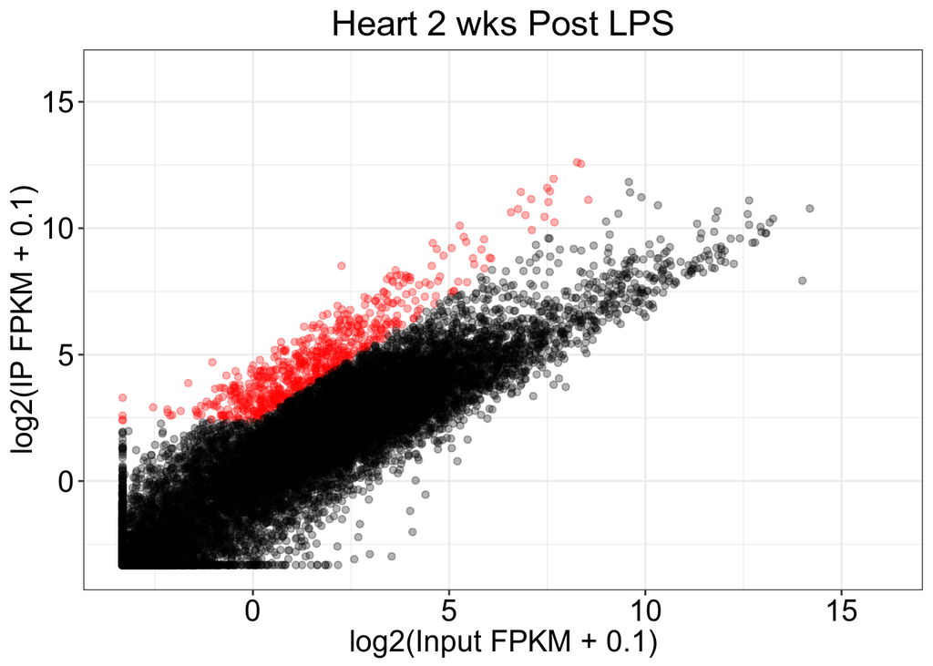

```r
Heart_LPS_2wk %>%
  ggplot(aes(log2(Heart_LPS_2wk_N +0.1), log2(Heart_LPS_2wk_IP+0.1), color = Enr)) +
  geom_point(alpha = 0.3)  + scale_color_manual(values=c("black", "red")) +
  theme_bw()  +
  labs(x = "log2(Input FPKM + 0.1)", y = "log2(IP FPKM + 0.1)",
       title = "Heart 2 wks Post LPS", family = 'Arial') +
  theme(plot.title = element_text(hjust = 0.5)) +
  theme(text = element_text(size = 16, family='Arial'), axis.text.x = element_text(size = 16, family = 'Arial', color = 'black'),
        axis.text.y = element_text(size = 16, family = 'Arial', color = 'black')) +
  theme(legend.position="none") +
  scale_x_continuous(limits=c(-3.35,16.1), breaks = c(0, 5, 10, 15)) +
  scale_y_continuous(limits=c(-3.35,16.1), breaks = c(0, 5, 10, 15))
```

Now I will reduce dimensionality using principle component analysis (PCA). First I filter our genes for coding genes only. Then transpose columns and rows. Next deleting any gene that has a zero value for all conditions.

```r
coding2 <- coding %>% `colnames<-`('tracking_id')

pcatrans1 <- cuffnorm1[,c(1,2,7)] %>% inner_join(coding2)
pcatrans2 <-spread(pcatrans1, key = 'tracking_id', value = 'FPKM')

pcatrans3 <- pcatrans2[,-1]
pcatrans4 <- pcatrans3[, colSums(pcatrans3 != 0) > 0]
```

Now I run the program prcomp to calculate principal components.

```r
pca_comp_lsp <- prcomp(pcatrans4, scale. = TRUE, center = TRUE, rank. = 100)
```

I want to add back the conditions that each value comes from.

```r
condition2 <- c("Heart_LPS_2wk_IP", "Heart_LPS_2wk_IP","Heart_LPS_2wk_N", "Heart_LPS_2wk_N",
                "Heart_LPS_4hr_IP", "Heart_LPS_4hr_IP", "Heart_LPS_4hr_N", "Heart_LPS_4hr_N",
                "Heart_PBS_IP", "Heart_PBS_IP", "Heart_PBS_N", "Heart_PBS_N",
                "Liver_LPS_2wk_IP","Liver_LPS_2wk_IP","Liver_LPS_2wk_N","Liver_LPS_2wk_N",
                "Liver_LPS_4hr_IP", "Liver_LPS_4hr_IP","Liver_LPS_4hr_N", "Liver_LPS_4hr_N",
                "Liver_PBS_IP", "Liver_PBS_IP","Liver_PBS_N", "Liver_PBS_N")


pca_lps_timecourse7 <- cbind(condition2, pcatrans4)
```

Now I will plot the PCA.

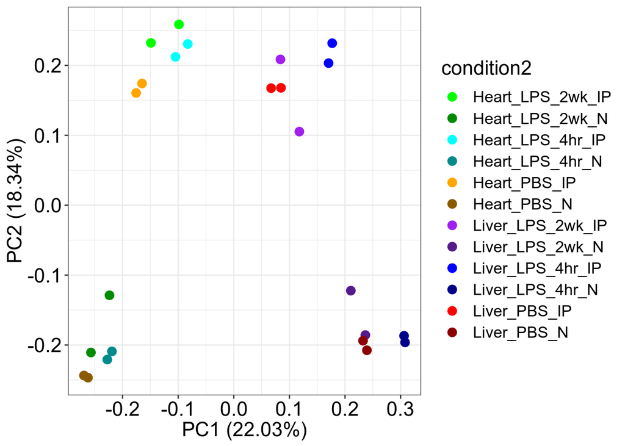

```r
autoplot(pca_comp_lsp, data = pca_lps_timecourse7, colour = 'condition2', frame = F, size=3,
         x= 1, y=2) +
  theme_bw() + scale_colour_manual(values = c("green",'green4',"cyan",'cyan4',
                                              "orange",'orange4',"purple",'purple4',
                                              "blue",'blue4',"red",'red4')) +
  theme(text = element_text(size = 16, family='Arial'),
        axis.text.x = element_text(size = 16, family = 'Arial', color = 'black'),
        axis.text.y = element_text(size = 16, family = 'Arial', color = 'black'))
```

You can see that PC1 divides the tissue heart and liver while PC2 divides input from IP.

Next I will compose a list of genes that are enriched in any condition.

```r
Enriched_list <- Liver_PBS_Enriched %>% full_join(Liver_LPS_4hr_Enriched) %>%
  full_join(Liver_LPS_2wk_Enriched) %>% full_join(Heart_PBS_Enriched) %>%
  full_join(Heart_LPS_4hr_Enriched) %>% full_join(Heart_LPS_2wk_Enriched) %>% `colnames<-`('tracking_id')
```

Now I will repeat the steps above to come up with a PCA for all the conditions using only enriched genes.

```r
pcatransEnr <- pcatrans1 %>% inner_join(Enriched_list)
pcatransEnr2 <-spread(pcatransEnr, key = 'tracking_id', value = 'FPKM')

pcatransEnr3 <- pcatransEnr2[,-1]
pcatransEnr4 <- pcatransEnr3[, colSums(pcatransEnr3 != 0) > 0]

pca_comp_lspEnr <- prcomp(pcatransEnr4, scale. = TRUE, center = TRUE, rank. = 100)

pca_lps_timecourseEnr <- cbind(condition2, pcatransEnr4)
```

Now to plot it.

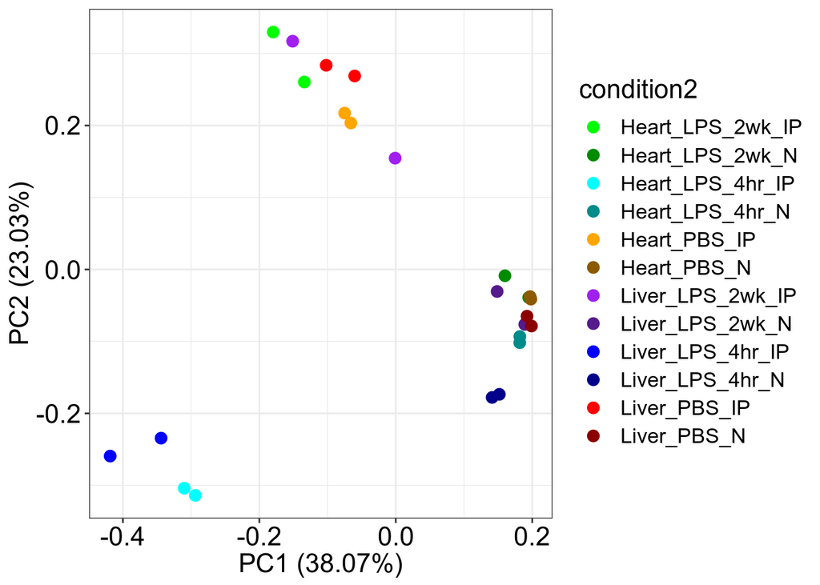

```r
autoplot(pca_comp_lspEnr, data = pca_lps_timecourseEnr, colour = 'condition2', frame = F, size=3,
         x= 1, y=2) +
  theme_bw() + scale_colour_manual(values = c("green",'green4',"cyan",'cyan4',
                                              "orange",'orange4',"purple",'purple4',
                                              "blue",'blue4',"red",'red4')) +
  theme(text = element_text(size = 16, family='Arial'),
        axis.text.x = element_text(size = 16, family = 'Arial', color = 'black'),
        axis.text.y = element_text(size = 16, family = 'Arial', color = 'black'))
```

Repeating the steps above with IPs only for all genes.

```r
pcatransIPs <- pcatrans2[c(1,2,5,6,9,10,13,14,17,18,21,22),]

pcatransIP2 <- pcatransIPs[,-1]
pcatransIP3 <- pcatransIP2[, colSums(pcatransIP2 != 0) > 0]

pca_comp_lspIP <- prcomp(pcatransIP3, scale. = TRUE, center = TRUE, rank. = 100)



condition <- c("Heart_LPS_2wk_IP", "Heart_LPS_2wk_IP",
                "Heart_LPS_4hr_IP", "Heart_LPS_4hr_IP",
                "Heart_PBS_IP", "Heart_PBS_IP",
                "Liver_LPS_2wk_IP","Liver_LPS_2wk_IP",
                "Liver_LPS_4hr_IP", "Liver_LPS_4hr_IP",
                "Liver_PBS_IP", "Liver_PBS_IP")


pca_lps_timecourseIP <- cbind(condition, pcatransIP3)
```

Now ploting it.

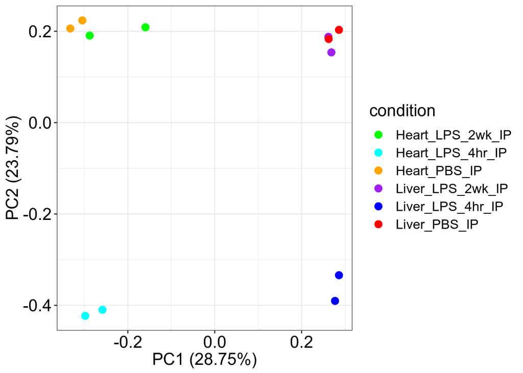

```r
autoplot(pca_comp_lspIP, data = pca_lps_timecourseIP, colour = 'condition', frame = F, size=3,
         x= 1, y=2) +
  theme_bw() + scale_colour_manual(values = c("green","cyan",
                                              "orange","purple",
                                              "blue","red")) +
  theme(text = element_text(size = 16, family='Arial'),
        axis.text.x = element_text(size = 16, family = 'Arial', color = 'black'),
        axis.text.y = element_text(size = 16, family = 'Arial', color = 'black'))
```

Now repeating the above steps for IPs only for enriched genes only.

```r
pcatransEnr2 <-spread(pcatransEnr, key = 'tracking_id', value = 'FPKM')
pcatransIPEnr <- pcatransEnr2[c(1,2,5,6,9,10,13,14,17,18,21,22),]


pcatransIPEnr2 <- pcatransIPEnr[,-1]
pcatransIPEnr3 <- pcatransIPEnr2[, colSums(pcatransIPEnr2 != 0) > 0]

pca_comp_lspEnrIP <- prcomp(pcatransIPEnr3, scale. = TRUE, center = TRUE, rank. = 100)

pca_lps_timecourseEnrIP <- cbind(condition, pcatransIPEnr3)
```

Now plotting it.

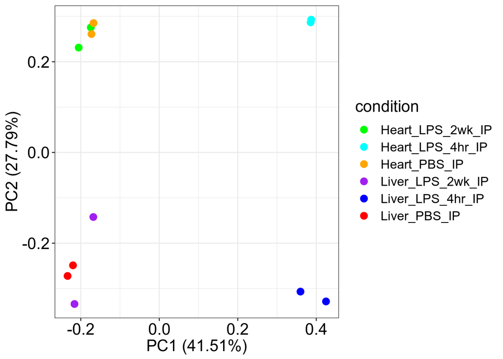

```r
autoplot(pca_comp_lspEnrIP, data = pca_lps_timecourseEnrIP, colour = 'condition', frame = F, size=3,
         x= 1, y=2) +
  theme_bw() + scale_colour_manual(values = c("green","cyan",
                                              "orange","purple",
                                              "blue","red")) +
  theme(text = element_text(size = 16, family='Arial'),
        axis.text.x = element_text(size = 16, family = 'Arial', color = 'black'),
        axis.text.y = element_text(size = 16, family = 'Arial', color = 'black'))
```